# 218Project

```python
## need to do: some null value can be replaced with mean, some population can be obtained from internet,do not need
## to delete all with null value, need to do it later if have time.
## normalized data
```

```python
import pandas as pd
import numpy as np
##import seaborn as sns
import matplotlib.pyplot as plt
from sklearn.preprocessing import StandardScaler
```

```python
lifeExpec = pd.read_csv('LifeExpectancyData.csv')
```

```python
lifeExpec.head()
```

|  | Country | Year | Status | Life expectancy | Adult Mortality | infant deaths | Alcohol | percentage expenditure | Hepatitis B | Measles | ... | Polio | Total expenditure | Diphtheria | HIV/AIDS | GDP | Population | thinness 1-19 years | thinness 5-9 years | Income composition of resources | Schooling |
| --- | --- | --- | --- | --- | --- | --- | --- | --- | --- | --- | --- | --- | --- | --- | --- | --- | --- | --- | --- | --- | --- |
| 0 | Afghanistan | 2015 | Developing | 65.0 | 263.0 | 62 | 0.01 | 71.279624 | 65.0 | 1154 | ... | 6.0 | 8.16 | 65.0 | 0.1 | 584.259210 | 33736494.0 | 17.2 | 17.3 | 0.479 | 10.1 |
| 1 | Afghanistan | 2014 | Developing | 59.9 | 271.0 | 64 | 0.01 | 73.523582 | 62.0 | 492 | ... | 58.0 | 8.18 | 62.0 | 0.1 | 612.696514 | 327582.0 | 17.5 | 17.5 | 0.476 | 10.0 |
| 2 | Afghanistan | 2013 | Developing | 59.9 | 268.0 | 66 | 0.01 | 73.219243 | 64.0 | 430 | ... | 62.0 | 8.13 | 64.0 | 0.1 | 631.744976 | 31731688.0 | 17.7 | 17.7 | 0.470 | 9.9 |
| 3 | Afghanistan | 2012 | Developing | 59.5 | 272.0 | 69 | 0.01 | 78.184215 | 67.0 | 2787 | ... | 67.0 | 8.52 | 67.0 | 0.1 | 669.959000 | 3696958.0 | 17.9 | 18.0 | 0.463 | 9.8 |
| 4 | Afghanistan | 2011 | Developing | 59.2 | 275.0 | 71 | 0.01 | 7.097109 | 68.0 | 3013 | ... | 68.0 | 7.87 | 68.0 | 0.1 | 63.537231 | 2978599.0 | 18.2 | 18.2 | 0.454 | 9.5 |

5 rows × 22 columns

```python
lifeExpec.shape
```

```
(2938, 22)
```

```python
lifeExpec.rename(columns={" BMI ":"BMI","Life expectancy ":"Life_Expectancy","Adult Mortality":"Adult_Mortality",
                   "infant deaths":"Infant_Deaths","percentage expenditure":"Percentage_Exp","Hepatitis B":"HepatitisB",
                  "Measles ":"Measles"," BMI ":"BMI","under-five deaths ":"Under_Five_Deaths","Diphtheria ":"Diphtheria",
                  " HIV/AIDS":"HIV/AIDS"," thinness  1-19 years":"thinness_1to19_years"," thinness 5-9 years":"thinness_5to9_years","Income composition of resources":"Income_Comp_Of_Resources",
                   "Total expenditure":"Tot_Exp"},inplace=True)
```

```python
lifeExpec.columns
```

```
Index(['Country', 'Year', 'Status', 'Life_Expectancy', 'Adult_Mortality',
       'Infant_Deaths', 'Alcohol', 'Percentage_Exp', 'HepatitisB', 'Measles',
       'BMI', 'Under_Five_Deaths', 'Polio', 'Tot_Exp', 'Diphtheria',
       'HIV/AIDS', 'GDP', 'Population', 'thinness_1to19_years',
       'thinness_5to9_years', 'Income_Comp_Of_Resources', 'Schooling'],
      dtype='object')
```

```python
lifeExpec.isnull().sum()
```

```
Country                       0
Year                          0
Status                        0
Life_Expectancy              10
Adult_Mortality              10
Infant_Deaths                 0
Alcohol                     194
Percentage_Exp                0
HepatitisB                  553
Measles                       0
BMI                          34
Under_Five_Deaths             0
Polio                        19
Tot_Exp                     226
Diphtheria                   19
HIV/AIDS                      0
GDP                         448
Population                  652
thinness_1to19_years         34
thinness_5to9_years          34
Income_Comp_Of_Resources    167
Schooling                   163
dtype: int64
```

```python
## replace developed country to 1,developing country to 2
##lifeExpec['Status'].replace({'Developing': 2,'Developed': 1 }, inplace = True)
```

```python
country_list = lifeExpec.Country.unique()
fill_list = ['Life_Expectancy','Adult_Mortality','Alcohol','HepatitisB','BMI','Polio','Tot_Exp','Diphtheria','GDP','Population','thinness_1to19_years','thinness_5to9_years','Income_Comp_Of_Resources','Schooling']
```

```python
for country in country_list:
    lifeExpec.loc[lifeExpec['Country'] == country,fill_list] = lifeExpec.loc[lifeExpec['Country'] == country,fill_list].interpolate()
```

```python
# Drop remaining null values after interpolation.
lifeExpec.dropna(inplace=True)
lifeExpec.shape
```

```
(1987, 22)
```

```python
countryNames = lifeExpec.Country.unique()
countryNames.size
```

```
133
```

```python
lifeExpec.describe()
```

|  | Year | Life_Expectancy | Adult_Mortality | Infant_Deaths | Alcohol | Percentage_Exp | HepatitisB | Measles | BMI | Under_Five_Deaths | Polio | Tot_Exp | Diphtheria | HIV/AIDS | GDP | Population | thinness_1to19_years | thinness_5to9_years | Income_Comp_Of_Resources | Schooling |
| --- | --- | --- | --- | --- | --- | --- | --- | --- | --- | --- | --- | --- | --- | --- | --- | --- | --- | --- | --- | --- |
| count | 1987.000000 | 1987.000000 | 1987.000000 | 1987.000000 | 1987.000000 | 1987.000000 | 1987.00000 | 1987.000000 | 1987.000000 | 1987.000000 | 1987.000000 | 1987.000000 | 1987.000000 | 1987.000000 | 1987.000000 | 1.987000e+03 | 1987.000000 | 1987.000000 | 1987.000000 | 1987.000000 |
| mean | 2006.984902 | 67.981782 | 175.187217 | 36.623553 | 4.455644 | 685.492318 | 73.86160 | 2729.561651 | 36.428636 | 50.932562 | 80.371917 | 5.902728 | 80.454454 | 2.274937 | 5392.335709 | 1.358390e+07 | 5.129995 | 5.199346 | 0.603453 | 11.639054 |
| std | 4.323147 | 9.706401 | 131.616942 | 138.784913 | 3.976733 | 1761.669050 | 29.02807 | 12102.389143 | 19.736138 | 188.933117 | 24.363376 | 2.287467 | 24.450153 | 6.005112 | 11480.810350 | 6.490113e+07 | 4.750149 | 4.844382 | 0.206026 | 3.212964 |
| min | 2000.000000 | 36.300000 | 1.000000 | 0.000000 | 0.010000 | 0.000000 | 2.00000 | 0.000000 | 1.400000 | 0.000000 | 3.000000 | 0.370000 | 2.000000 | 0.100000 | 1.681350 | 3.400000e+01 | 0.100000 | 0.100000 | 0.000000 | 0.000000 |
| 25% | 2003.000000 | 61.700000 | 75.000000 | 1.000000 | 0.830000 | 29.469887 | 64.00000 | 0.000000 | 18.150000 | 1.000000 | 74.000000 | 4.360000 | 75.500000 | 0.100000 | 384.553107 | 1.967480e+05 | 1.600000 | 1.600000 | 0.473000 | 9.700000 |
| 50% | 2007.000000 | 69.900000 | 153.000000 | 4.000000 | 3.770000 | 104.314473 | 86.00000 | 20.000000 | 38.700000 | 4.000000 | 91.000000 | 5.800000 | 91.000000 | 0.100000 | 1334.651896 | 1.396861e+06 | 3.300000 | 3.400000 | 0.648000 | 11.900000 |
| 75% | 2011.000000 | 74.700000 | 243.000000 | 25.000000 | 7.190000 | 470.870122 | 95.00000 | 499.500000 | 55.000000 | 36.000000 | 96.000000 | 7.385000 | 96.000000 | 1.400000 | 4441.530655 | 7.625918e+06 | 7.600000 | 7.700000 | 0.745000 | 13.700000 |
| max | 2015.000000 | 89.000000 | 723.000000 | 1800.000000 | 17.870000 | 18961.348600 | 99.00000 | 212183.000000 | 77.100000 | 2500.000000 | 99.000000 | 14.390000 | 99.000000 | 50.600000 | 119172.741800 | 1.293859e+09 | 27.700000 | 28.600000 | 0.936000 | 20.700000 |

```python
round(lifeExpec[['Status','Life_Expectancy']].groupby(['Status']).mean(),2)
```

| Status | Life_Expectancy |
| --- | --- |
| Developed | 78.83 |
| Developing | 66.16 |

```python
l =(round(lifeExpec.groupby('Status')['Life_Expectancy'].mean(), 2).to_numpy())
```

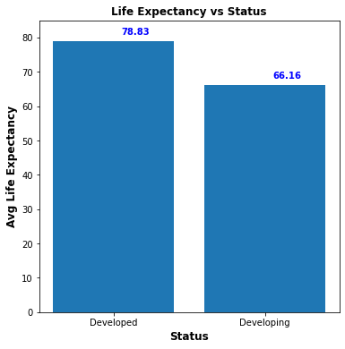

```python
## life Expectancy vs status
l =(round(lifeExpec.groupby('Status')['Life_Expectancy'].mean(), 2).to_numpy())
plt.figure(figsize=(6,6))
plt.bar(lifeExpec.groupby('Status')['Status'].count().index,lifeExpec.groupby('Status')['Life_Expectancy'].mean())
plt.xlabel("Status",fontsize=12,fontweight='bold')
plt.ylabel("Avg Life Expectancy",fontsize=12,fontweight='bold')
plt.ylim(0, 85)
plt.title("Life Expectancy vs Status",fontweight='bold')
for i, v in enumerate(l):
    plt.text(i +0.05,v +2,str(v), color='blue', fontweight='bold' )
plt.show()
```

```python
import scipy.stats as stats
stats.ttest_ind(lifeExpec.loc[lifeExpec['Status']=='Developed','Life_Expectancy'],lifeExpec.loc[lifeExpec['Status']=='Developing','Life_Expectancy'])
```

```
Ttest_indResult(statistic=22.92439377113489, pvalue=2.2504696584331004e-103)
```

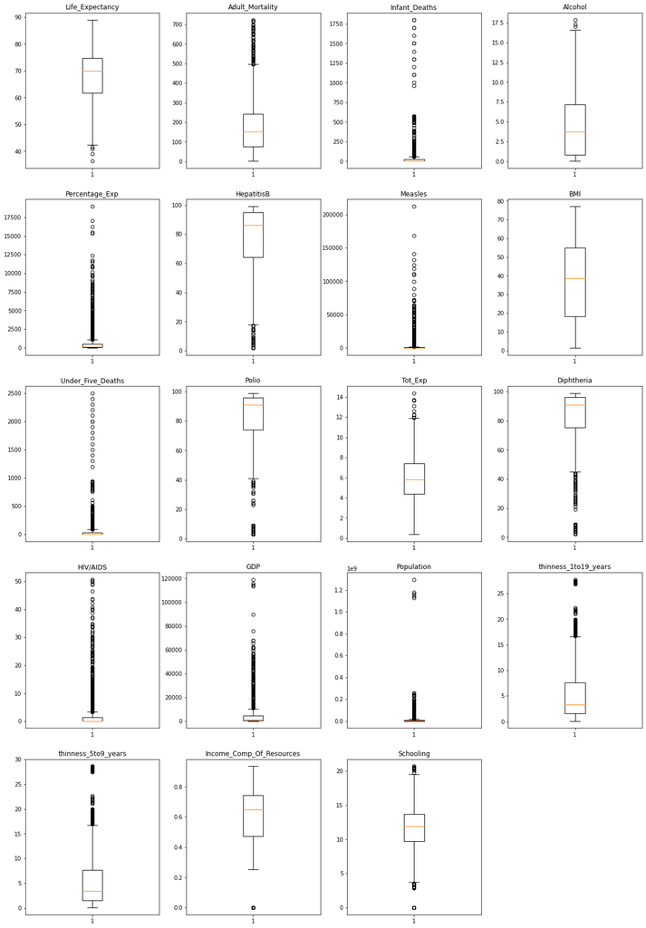

```python
## detect outliers using boxplot
col_dict = {'Life_Expectancy':1,'Adult_Mortality':2,'Infant_Deaths':3,'Alcohol':4,'Percentage_Exp':5,'HepatitisB':6,'Measles':7,'BMI':8,'Under_Five_Deaths':9,'Polio':10,'Tot_Exp':11,'Diphtheria':12,'HIV/AIDS':13,'GDP':14,'Population':15,'thinness_1to19_years':16,
            'thinness_5to9_years':17,'Income_Comp_Of_Resources':18,'Schooling':19}
plt.figure(figsize=(20,30))

for variable,i in col_dict.items():
                     plt.subplot(5,4,i)
                     plt.boxplot(lifeExpec[variable],whis=1.5)
                     plt.title(variable)

plt.show()
```

```python
## check life Expecancy
lifeExpec[lifeExpec["Life_Expectancy"] < 45]
```

|  | Country | Year | Status | Life_Expectancy | Adult_Mortality | Infant_Deaths | Alcohol | Percentage_Exp | HepatitisB | Measles | ... | Polio | Tot_Exp | Diphtheria | HIV/AIDS | GDP | Population | thinness_1to19_years | thinness_5to9_years | Income_Comp_Of_Resources | Schooling |
| --- | --- | --- | --- | --- | --- | --- | --- | --- | --- | --- | --- | --- | --- | --- | --- | --- | --- | --- | --- | --- | --- |
| 1127 | Haiti | 2010 | Developing | 36.3 | 682.0 | 23 | 5.76 | 36.292918 | 68.0 | 0 | ... | 66.0 | 8.90 | 66.0 | 1.9 | 662.279518 | 9999617.0 | 4.0 | 4.0 | 0.470 | 8.6 |
| 1484 | Lesotho | 2005 | Developing | 44.5 | 675.0 | 5 | 2.67 | 57.903698 | 87.0 | 0 | ... | 88.0 | 6.30 | 89.0 | 34.8 | 862.946312 | 1949543.0 | 9.3 | 9.2 | 0.437 | 10.7 |
| 1485 | Lesotho | 2004 | Developing | 44.8 | 666.0 | 5 | 1.80 | 67.913618 | 6.0 | 31 | ... | 89.0 | 6.96 | 9.0 | 34.6 | 781.514594 | 1933728.0 | 9.7 | 9.7 | 0.439 | 10.7 |
| 1582 | Malawi | 2003 | Developing | 44.6 | 613.0 | 43 | 1.08 | 4.375316 | 84.0 | 167 | ... | 85.0 | 6.35 | 84.0 | 24.2 | 26.152517 | 12336687.0 | 7.6 | 7.5 | 0.362 | 10.3 |
| 1583 | Malawi | 2002 | Developing | 44.0 | 67.0 | 46 | 1.10 | 3.885395 | 64.0 | 92 | ... | 79.0 | 4.82 | 64.0 | 24.7 | 29.979898 | 1213711.0 | 7.7 | 7.6 | 0.388 | 10.4 |
| 1584 | Malawi | 2001 | Developing | 43.5 | 599.0 | 48 | 1.15 | 12.797606 | 64.0 | 150 | ... | 86.0 | 5.70 | 9.0 | 25.1 | 146.761540 | 11695863.0 | 7.9 | 7.7 | 0.387 | 10.1 |
| 1585 | Malawi | 2000 | Developing | 43.1 | 588.0 | 51 | 1.18 | 13.762702 | 64.0 | 304 | ... | 73.0 | 6.70 | 75.0 | 25.5 | 153.259487 | 11376172.0 | 8.0 | 7.9 | 0.391 | 10.7 |
| 2306 | Sierra Leone | 2006 | Developing | 44.3 | 464.0 | 30 | 3.80 | 38.000758 | 63.0 | 33 | ... | 65.0 | 1.68 | 64.0 | 2.2 | 322.313468 | 5848692.0 | 9.1 | 9.1 | 0.348 | 8.0 |
| 2307 | Sierra Leone | 2005 | Developing | 43.3 | 48.0 | 30 | 3.83 | 42.088929 | 63.0 | 29 | ... | 67.0 | 12.25 | 65.0 | 2.2 | 287.689194 | 5658379.0 | 9.3 | 9.3 | 0.341 | 7.8 |
| 2308 | Sierra Leone | 2004 | Developing | 42.3 | 496.0 | 30 | 3.99 | 38.524548 | 63.0 | 7 | ... | 69.0 | 11.66 | 65.0 | 2.1 | 263.145817 | 5439695.0 | 9.5 | 9.5 | 0.332 | 7.6 |
| 2309 | Sierra Leone | 2003 | Developing | 41.5 | 57.0 | 30 | 4.07 | 38.614732 | 63.0 | 586 | ... | 66.0 | 11.69 | 73.0 | 1.9 | 263.761831 | 5199549.0 | 9.7 | 9.8 | 0.322 | 7.4 |
| 2311 | Sierra Leone | 2001 | Developing | 41.0 | 519.0 | 30 | 4.21 | 33.346915 | 63.0 | 649 | ... | 38.0 | 11.83 | 38.0 | 1.5 | 227.779471 | 4739147.0 | 1.1 | 1.2 | 0.302 | 7.0 |
| 2312 | Sierra Leone | 2000 | Developing | 39.0 | 533.0 | 29 | 3.97 | 20.395683 | 63.0 | 3575 | ... | 46.0 | 13.63 | 44.0 | 1.2 | 139.314773 | 4564297.0 | 1.3 | 1.4 | 0.292 | 6.7 |
| 2920 | Zambia | 2001 | Developing | 44.6 | 611.0 | 43 | 2.61 | 46.830275 | 82.0 | 16997 | ... | 86.0 | 6.56 | 85.0 | 18.6 | 378.273624 | 1824125.0 | 7.4 | 7.4 | 0.424 | 9.8 |
| 2921 | Zambia | 2000 | Developing | 43.8 | 614.0 | 44 | 2.62 | 45.616880 | 82.0 | 30930 | ... | 85.0 | 7.16 | 85.0 | 18.7 | 341.955625 | 1531221.0 | 7.5 | 7.5 | 0.418 | 9.6 |
| 2932 | Zimbabwe | 2005 | Developing | 44.6 | 717.0 | 28 | 4.14 | 8.717409 | 65.0 | 420 | ... | 69.0 | 6.44 | 68.0 | 30.3 | 444.765750 | 129432.0 | 9.0 | 9.0 | 0.406 | 9.3 |
| 2933 | Zimbabwe | 2004 | Developing | 44.3 | 723.0 | 27 | 4.36 | 0.000000 | 68.0 | 31 | ... | 67.0 | 7.13 | 65.0 | 33.6 | 454.366654 | 12777511.0 | 9.4 | 9.4 | 0.407 | 9.2 |
| 2934 | Zimbabwe | 2003 | Developing | 44.5 | 715.0 | 26 | 4.06 | 0.000000 | 7.0 | 998 | ... | 7.0 | 6.52 | 68.0 | 36.7 | 453.351155 | 12633897.0 | 9.8 | 9.9 | 0.418 | 9.5 |
| 2935 | Zimbabwe | 2002 | Developing | 44.8 | 73.0 | 25 | 4.43 | 0.000000 | 73.0 | 304 | ... | 73.0 | 6.53 | 71.0 | 39.8 | 57.348340 | 125525.0 | 1.2 | 1.3 | 0.427 | 10.0 |

19 rows × 22 columns

```python
lifeExpec[lifeExpec["Country"] == 'Sierra Leone']['Life_Expectancy']
```

```
2298    48.1
2299    54.0
2300    49.7
2301    48.9
2302    48.1
2303    47.1
2304    46.2
2305    45.3
2306    44.3
2307    43.3
2308    42.3
2309    41.5
2310    48.0
2311    41.0
2312    39.0
Name: Life_Expectancy, dtype: float64
```

```python
lifeExpec[lifeExpec["Country"] == 'Malawi']['Life_Expectancy']
```

```
1571    57.6
1572    56.7
1573    55.3
1574    54.1
1575    52.9
1576    51.5
1577    50.0
1578    48.5
1579    47.1
1580    46.0
1581    45.1
1582    44.6
1583    44.0
1584    43.5
1585    43.1
Name: Life_Expectancy, dtype: float64
```

```python
lifeExpec[lifeExpec["Country"] == 'Lesotho']['Life_Expectancy']
```

```
1475    52.1
1476    52.1
1477    52.2
1478    52.3
1479    51.1
1480    49.4
1481    47.8
1482    46.2
1483    45.3
1484    44.5
1485    44.8
1486    45.5
1487    46.4
1488    47.8
1489    49.3
Name: Life_Expectancy, dtype: float64
```

```python
lifeExpec[lifeExpec["Country"] == 'Zambia']['Life_Expectancy']
```

```
2907    61.1
2908    63.0
2909    59.2
2910    58.2
2911    58.0
2912    57.4
2913    55.7
2914    52.6
2915    58.0
2916    49.3
2917    47.9
2918    46.4
2919    45.5
2920    44.6
2921    43.8
Name: Life_Expectancy, dtype: float64
```

```python
lifeExpec[lifeExpec["Country"] == 'Zimbabwe']['Life_Expectancy']
```

```
2923    59.2
2924    58.0
2925    56.6
2926    54.9
2927    52.4
2928    50.0
2929    48.2
2930    46.6
2931    45.4
2932    44.6
2933    44.3
2934    44.5
2935    44.8
2936    45.3
2937    46.0
Name: Life_Expectancy, dtype: float64
```

Based on the analysis above, the life Expectancy low is mainly because these data are from developing country. Here we will keep the data.

```python
## check  Adult_Mortality
lifeExpec[lifeExpec["Adult_Mortality"] > 500]
```

|  | Country | Year | Status | Life_Expectancy | Adult_Mortality | Infant_Deaths | Alcohol | Percentage_Exp | HepatitisB | Measles | ... | Polio | Tot_Exp | Diphtheria | HIV/AIDS | GDP | Population | thinness_1to19_years | thinness_5to9_years | Income_Comp_Of_Resources | Schooling |
| --- | --- | --- | --- | --- | --- | --- | --- | --- | --- | --- | --- | --- | --- | --- | --- | --- | --- | --- | --- | --- | --- |
| 346 | Botswana | 2005 | Developing | 51.7 | 566.0 | 2 | 6.37 | 629.842564 | 92.0 | 5 | ... | 96.0 | 5.62 | 96.0 | 20.6 | 5351.253732 | 1855852.0 | 1.0 | 9.9 | 0.593 | 11.9 |
| 347 | Botswana | 2004 | Developing | 48.1 | 652.0 | 2 | 4.90 | 469.582390 | 91.0 | 1 | ... | 96.0 | 5.56 | 96.0 | 28.4 | 4896.583835 | 182933.0 | 1.5 | 1.4 | 0.580 | 11.8 |
| 348 | Botswana | 2003 | Developing | 46.4 | 693.0 | 2 | 5.51 | 299.367125 | 9.0 | 59 | ... | 96.0 | 4.65 | 96.0 | 31.9 | 4163.659600 | 184339.0 | 1.9 | 1.8 | 0.567 | 11.8 |
| 349 | Botswana | 2002 | Developing | 46.0 | 699.0 | 2 | 6.41 | 6.330007 | 88.0 | 7 | ... | 97.0 | 6.47 | 97.0 | 34.6 | 355.618382 | 1779953.0 | 11.4 | 11.3 | 0.558 | 11.9 |
| 350 | Botswana | 2001 | Developing | 46.7 | 679.0 | 2 | 5.48 | 306.952735 | 87.0 | 1 | ... | 97.0 | 5.73 | 97.0 | 37.2 | 3128.977930 | 1754935.0 | 11.8 | 11.8 | 0.560 | 11.8 |
| 351 | Botswana | 2000 | Developing | 47.8 | 647.0 | 2 | 5.37 | 250.891648 | 86.0 | 2672 | ... | 97.0 | 4.64 | 97.0 | 38.8 | 3349.688230 | 172834.0 | 12.3 | 12.2 | 0.559 | 11.7 |
| 522 | Central African Republic | 2005 | Developing | 45.9 | 511.0 | 17 | 1.50 | 40.922080 | 42.0 | 471 | ... | 47.0 | 4.29 | 54.0 | 11.2 | 327.114946 | 412791.0 | 9.7 | 9.7 | 0.319 | 5.9 |
| 523 | Central African Republic | 2004 | Developing | 45.7 | 512.0 | 17 | 1.50 | 41.501117 | 42.0 | 1233 | ... | 45.0 | 4.10 | 51.0 | 12.0 | 313.215980 | 45536.0 | 9.9 | 9.9 | 0.315 | 5.7 |
| 865 | Eritrea | 2000 | Developing | 45.3 | 593.0 | 7 | 0.83 | 0.735940 | 86.0 | 789 | ... | 82.0 | 4.43 | 81.0 | 1.9 | 28.196949 | 339281.0 | 1.2 | 1.1 | 0.000 | 3.9 |
| 1127 | Haiti | 2010 | Developing | 36.3 | 682.0 | 23 | 5.76 | 36.292918 | 68.0 | 0 | ... | 66.0 | 8.90 | 66.0 | 1.9 | 662.279518 | 9999617.0 | 4.0 | 4.0 | 0.470 | 8.6 |
| 1475 | Lesotho | 2014 | Developing | 52.1 | 522.0 | 4 | 0.01 | 162.127812 | 93.0 | 0 | ... | 9.0 | 1.62 | 93.0 | 9.4 | 1174.839214 | 2145785.0 | 5.8 | 5.6 | 0.491 | 10.8 |
| 1476 | Lesotho | 2013 | Developing | 52.1 | 518.0 | 4 | 0.01 | 153.344315 | 93.0 | 516 | ... | 9.0 | 11.70 | 93.0 | 9.6 | 1196.133500 | 2117361.0 | 6.1 | 5.9 | 0.484 | 11.1 |
| 1477 | Lesotho | 2012 | Developing | 52.2 | 513.0 | 4 | 0.01 | 168.134899 | 95.0 | 179 | ... | 93.0 | 11.14 | 95.0 | 9.0 | 1281.516000 | 289928.0 | 6.4 | 6.2 | 0.479 | 11.0 |
| 1479 | Lesotho | 2010 | Developing | 51.1 | 527.0 | 4 | 2.71 | 154.870600 | 93.0 | 2488 | ... | 92.0 | 1.87 | 93.0 | 13.4 | 1173.262120 | 24551.0 | 7.2 | 7.0 | 0.464 | 10.9 |
| 1480 | Lesotho | 2009 | Developing | 49.4 | 566.0 | 4 | 2.75 | 104.314473 | 91.0 | 0 | ... | 89.0 | 9.80 | 91.0 | 18.2 | 923.136931 | 21929.0 | 7.6 | 7.4 | 0.453 | 10.8 |
| 1481 | Lesotho | 2008 | Developing | 47.8 | 592.0 | 5 | 2.75 | 91.854328 | 88.0 | 0 | ... | 86.0 | 8.85 | 88.0 | 27.3 | 934.428563 | 199993.0 | 8.0 | 7.8 | 0.447 | 10.7 |
| 1482 | Lesotho | 2007 | Developing | 46.2 | 633.0 | 4 | 2.69 | 9.184327 | 9.0 | 2 | ... | 87.0 | 8.47 | 88.0 | 30.0 | 918.432717 | 1982287.0 | 8.4 | 8.3 | 0.440 | 10.6 |
| 1483 | Lesotho | 2006 | Developing | 45.3 | 654.0 | 5 | 2.61 | 71.155776 | 91.0 | 1 | ... | 88.0 | 7.12 | 89.0 | 34.1 | 915.775754 | 1965662.0 | 8.8 | 8.7 | 0.437 | 10.7 |
| 1484 | Lesotho | 2005 | Developing | 44.5 | 675.0 | 5 | 2.67 | 57.903698 | 87.0 | 0 | ... | 88.0 | 6.30 | 89.0 | 34.8 | 862.946312 | 1949543.0 | 9.3 | 9.2 | 0.437 | 10.7 |
| 1485 | Lesotho | 2004 | Developing | 44.8 | 666.0 | 5 | 1.80 | 67.913618 | 6.0 | 31 | ... | 89.0 | 6.96 | 9.0 | 34.6 | 781.514594 | 1933728.0 | 9.7 | 9.7 | 0.439 | 10.7 |
| 1486 | Lesotho | 2003 | Developing | 45.5 | 648.0 | 5 | 1.99 | 5.300902 | 17.0 | 1 | ... | 9.0 | 7.13 | 9.0 | 33.8 | 63.636279 | 191897.0 | 1.2 | 1.1 | 0.440 | 10.5 |
| 1487 | Lesotho | 2002 | Developing | 46.4 | 622.0 | 5 | 2.95 | 3.534574 | 17.0 | 0 | ... | 84.0 | 6.91 | 84.0 | 32.5 | 47.893950 | 192312.0 | 1.6 | 1.6 | 0.446 | 10.4 |
| 1488 | Lesotho | 2001 | Developing | 47.8 | 586.0 | 5 | 2.86 | 38.571870 | 17.0 | 217 | ... | 78.0 | 7.53 | 78.0 | 31.2 | 437.819184 | 1885955.0 | 11.1 | 11.1 | 0.443 | 10.3 |
| 1489 | Lesotho | 2000 | Developing | 49.3 | 543.0 | 5 | 3.10 | 29.866165 | 17.0 | 660 | ... | 82.0 | 6.92 | 83.0 | 29.8 | 474.819788 | 1868699.0 | 11.5 | 11.6 | 0.445 | 9.6 |
| 1577 | Malawi | 2008 | Developing | 50.0 | 525.0 | 36 | 1.27 | 74.344830 | 91.0 | 20 | ... | 92.0 | 1.70 | 91.0 | 16.9 | 372.842678 | 14271234.0 | 7.0 | 6.9 | 0.400 | 9.6 |
| 1578 | Malawi | 2007 | Developing | 48.5 | 559.0 | 37 | 1.18 | 4.269511 | 87.0 | 143 | ... | 88.0 | 9.31 | 87.0 | 19.3 | 32.222727 | 1384969.0 | 7.1 | 7.0 | 0.387 | 9.7 |
| 1579 | Malawi | 2006 | Developing | 47.1 | 587.0 | 38 | 1.18 | 6.847034 | 99.0 | 1 | ... | 99.0 | 8.99 | 99.0 | 21.1 | 297.697121 | 13429262.0 | 7.3 | 7.1 | 0.377 | 9.6 |
| 1581 | Malawi | 2004 | Developing | 45.1 | 615.0 | 40 | 1.11 | 58.135833 | 89.0 | 1116 | ... | 94.0 | 7.82 | 89.0 | 23.4 | 274.225629 | 1267638.0 | 7.5 | 7.4 | 0.366 | 10.0 |
| 1582 | Malawi | 2003 | Developing | 44.6 | 613.0 | 43 | 1.08 | 4.375316 | 84.0 | 167 | ... | 85.0 | 6.35 | 84.0 | 24.2 | 26.152517 | 12336687.0 | 7.6 | 7.5 | 0.362 | 10.3 |
| 1584 | Malawi | 2001 | Developing | 43.5 | 599.0 | 48 | 1.15 | 12.797606 | 64.0 | 150 | ... | 86.0 | 5.70 | 9.0 | 25.1 | 146.761540 | 11695863.0 | 7.9 | 7.7 | 0.387 | 10.1 |
| 1585 | Malawi | 2000 | Developing | 43.1 | 588.0 | 51 | 1.18 | 13.762702 | 64.0 | 304 | ... | 73.0 | 6.70 | 75.0 | 25.5 | 153.259487 | 11376172.0 | 8.0 | 7.9 | 0.391 | 10.7 |
| 2310 | Sierra Leone | 2002 | Developing | 48.0 | 513.0 | 30 | 4.06 | 36.591149 | 63.0 | 568 | ... | 54.0 | 11.96 | 53.0 | 1.7 | 249.939542 | 4957216.0 | 9.9 | 1.0 | 0.306 | 7.2 |
| 2311 | Sierra Leone | 2001 | Developing | 41.0 | 519.0 | 30 | 4.21 | 33.346915 | 63.0 | 649 | ... | 38.0 | 11.83 | 38.0 | 1.5 | 227.779471 | 4739147.0 | 1.1 | 1.2 | 0.302 | 7.0 |
| 2312 | Sierra Leone | 2000 | Developing | 39.0 | 533.0 | 29 | 3.97 | 20.395683 | 63.0 | 3575 | ... | 46.0 | 13.63 | 44.0 | 1.2 | 139.314773 | 4564297.0 | 1.3 | 1.4 | 0.292 | 6.7 |
| 2498 | Swaziland | 2006 | Developing | 47.8 | 564.0 | 3 | 5.53 | 437.080244 | 93.0 | 0 | ... | 88.0 | 6.81 | 87.0 | 43.7 | 2937.367230 | 112514.0 | 6.9 | 7.1 | 0.502 | 9.9 |
| 2502 | Swaziland | 2002 | Developing | 46.4 | 587.0 | 3 | 5.52 | 131.042127 | 88.0 | 37 | ... | 87.0 | 5.16 | 85.0 | 49.9 | 1324.996228 | 1893.0 | 8.6 | 8.8 | 0.502 | 9.2 |
| 2503 | Swaziland | 2001 | Developing | 47.1 | 568.0 | 3 | 6.72 | 143.619732 | 86.0 | 49 | ... | 87.0 | 5.11 | 84.0 | 48.8 | 1437.634951 | 172927.0 | 9.0 | 9.2 | 0.506 | 9.3 |
| 2504 | Swaziland | 2000 | Developing | 48.4 | 536.0 | 3 | 7.19 | 25.216833 | 83.0 | 10 | ... | 87.0 | 5.26 | 84.0 | 46.4 | 1637.456700 | 161468.0 | 9.4 | 9.6 | 0.516 | 9.4 |
| 2727 | Uganda | 2002 | Developing | 48.8 | 523.0 | 112 | 10.42 | 2.690898 | 29.0 | 49871 | ... | 57.0 | 7.78 | 57.0 | 10.0 | 24.242323 | 2571848.0 | 6.8 | 6.8 | 0.404 | 11.0 |
| 2728 | Uganda | 2001 | Developing | 47.7 | 539.0 | 115 | 10.57 | 26.976252 | 29.0 | 48543 | ... | 56.0 | 7.26 | 55.0 | 10.8 | 234.984775 | 24854892.0 | 6.9 | 6.9 | 0.396 | 10.8 |
| 2729 | Uganda | 2000 | Developing | 46.6 | 554.0 | 116 | 10.47 | 22.594475 | 29.0 | 42554 | ... | 55.0 | 6.77 | 52.0 | 11.6 | 257.633690 | 2439274.0 | 7.0 | 7.0 | 0.382 | 9.8 |
| 2915 | Zambia | 2006 | Developing | 58.0 | 526.0 | 33 | 2.25 | 1.860004 | 81.0 | 459 | ... | 83.0 | 6.11 | 81.0 | 15.9 | 13.154199 | 12383446.0 | 7.0 | 6.9 | 0.479 | 10.9 |
| 2916 | Zambia | 2005 | Developing | 49.3 | 554.0 | 34 | 2.33 | 121.879331 | 82.0 | 45 | ... | 84.0 | 7.56 | 82.0 | 17.0 | 691.317816 | 1252156.0 | 7.1 | 7.0 | 0.467 | 10.7 |
| 2917 | Zambia | 2004 | Developing | 47.9 | 578.0 | 36 | 2.46 | 8.369852 | 82.0 | 35 | ... | 84.0 | 7.33 | 83.0 | 17.6 | 53.277222 | 11731746.0 | 7.2 | 7.1 | 0.456 | 10.5 |
| 2920 | Zambia | 2001 | Developing | 44.6 | 611.0 | 43 | 2.61 | 46.830275 | 82.0 | 16997 | ... | 86.0 | 6.56 | 85.0 | 18.6 | 378.273624 | 1824125.0 | 7.4 | 7.4 | 0.424 | 9.8 |
| 2921 | Zambia | 2000 | Developing | 43.8 | 614.0 | 44 | 2.62 | 45.616880 | 82.0 | 30930 | ... | 85.0 | 7.16 | 85.0 | 18.7 | 341.955625 | 1531221.0 | 7.5 | 7.5 | 0.418 | 9.6 |
| 2927 | Zimbabwe | 2010 | Developing | 52.4 | 527.0 | 29 | 5.21 | 53.308581 | 9.0 | 9696 | ... | 89.0 | 5.37 | 89.0 | 15.7 | 713.635620 | 1486317.0 | 7.1 | 7.0 | 0.436 | 10.0 |
| 2928 | Zimbabwe | 2009 | Developing | 50.0 | 587.0 | 30 | 4.64 | 1.040021 | 73.0 | 853 | ... | 69.0 | 6.26 | 73.0 | 18.1 | 65.824121 | 1381599.0 | 7.5 | 7.4 | 0.419 | 9.9 |
| 2929 | Zimbabwe | 2008 | Developing | 48.2 | 632.0 | 30 | 3.56 | 20.843429 | 75.0 | 0 | ... | 75.0 | 4.96 | 75.0 | 20.5 | 325.678573 | 13558469.0 | 7.8 | 7.8 | 0.421 | 9.7 |
| 2932 | Zimbabwe | 2005 | Developing | 44.6 | 717.0 | 28 | 4.14 | 8.717409 | 65.0 | 420 | ... | 69.0 | 6.44 | 68.0 | 30.3 | 444.765750 | 129432.0 | 9.0 | 9.0 | 0.406 | 9.3 |
| 2933 | Zimbabwe | 2004 | Developing | 44.3 | 723.0 | 27 | 4.36 | 0.000000 | 68.0 | 31 | ... | 67.0 | 7.13 | 65.0 | 33.6 | 454.366654 | 12777511.0 | 9.4 | 9.4 | 0.407 | 9.2 |
| 2934 | Zimbabwe | 2003 | Developing | 44.5 | 715.0 | 26 | 4.06 | 0.000000 | 7.0 | 998 | ... | 7.0 | 6.52 | 68.0 | 36.7 | 453.351155 | 12633897.0 | 9.8 | 9.9 | 0.418 | 9.5 |
| 2936 | Zimbabwe | 2001 | Developing | 45.3 | 686.0 | 25 | 1.72 | 0.000000 | 76.0 | 529 | ... | 76.0 | 6.16 | 75.0 | 42.1 | 548.587312 | 12366165.0 | 1.6 | 1.7 | 0.427 | 9.8 |
| 2937 | Zimbabwe | 2000 | Developing | 46.0 | 665.0 | 24 | 1.68 | 0.000000 | 79.0 | 1483 | ... | 78.0 | 7.10 | 78.0 | 43.5 | 547.358879 | 12222251.0 | 11.0 | 11.2 | 0.434 | 9.8 |

54 rows × 22 columns

```python
lifeExpec[lifeExpec["Country"] == 'Central African Republic']
```

|  | Country | Year | Status | Life_Expectancy | Adult_Mortality | Infant_Deaths | Alcohol | Percentage_Exp | HepatitisB | Measles | ... | Polio | Tot_Exp | Diphtheria | HIV/AIDS | GDP | Population | thinness_1to19_years | thinness_5to9_years | Income_Comp_Of_Resources | Schooling |
| --- | --- | --- | --- | --- | --- | --- | --- | --- | --- | --- | --- | --- | --- | --- | --- | --- | --- | --- | --- | --- | --- |
| 513 | Central African Republic | 2014 | Developing | 58.0 | 437.0 | 15 | 0.01 | 53.439643 | 47.0 | 210 | ... | 47.0 | 4.20 | 47.0 | 4.5 | 377.132274 | 4515392.0 | 8.4 | 8.3 | 0.345 | 7.1 |
| 514 | Central African Republic | 2013 | Developing | 49.9 | 451.0 | 16 | 0.01 | 52.377666 | 23.0 | 596 | ... | 23.0 | 3.82 | 23.0 | 5.1 | 337.484961 | 4499653.0 | 8.5 | 8.5 | 0.370 | 7.1 |
| 515 | Central African Republic | 2012 | Developing | 53.0 | 439.0 | 16 | 0.01 | 7.344808 | 47.0 | 141 | ... | 47.0 | 3.62 | 47.0 | 5.1 | 486.411140 | 449416.0 | 8.7 | 8.6 | 0.366 | 7.1 |
| 516 | Central African Republic | 2011 | Developing | 49.8 | 443.0 | 16 | 1.66 | 58.529475 | 47.0 | 679 | ... | 47.0 | 3.73 | 47.0 | 5.8 | 494.336779 | 4476153.0 | 8.8 | 8.8 | 0.361 | 6.8 |
| 517 | Central African Republic | 2010 | Developing | 49.2 | 446.0 | 17 | 1.67 | 43.483592 | 45.0 | 2 | ... | 46.0 | 3.90 | 45.0 | 6.6 | 446.443449 | 4448525.0 | 9.0 | 8.9 | 0.352 | 6.6 |
| 518 | Central African Republic | 2009 | Developing | 48.6 | 453.0 | 17 | 1.56 | 40.451569 | 42.0 | 11 | ... | 45.0 | 3.58 | 42.0 | 7.3 | 449.961839 | 44423.0 | 9.1 | 9.1 | 0.345 | 6.4 |
| 519 | Central African Republic | 2008 | Developing | 47.6 | 477.0 | 17 | 1.52 | 67.341375 | 42.0 | 12 | ... | 46.0 | 4.30 | 45.0 | 8.3 | 456.861433 | 4345386.0 | 9.3 | 9.2 | 0.338 | 6.3 |
| 520 | Central African Republic | 2007 | Developing | 46.8 | 495.0 | 17 | 1.50 | 60.048848 | 42.0 | 49 | ... | 46.0 | 4.40 | 48.0 | 9.0 | 397.148467 | 42758.0 | 9.4 | 9.4 | 0.330 | 6.2 |
| 521 | Central African Republic | 2006 | Developing | 46.3 | 56.0 | 17 | 1.54 | 46.901179 | 42.0 | 3 | ... | 47.0 | 3.99 | 51.0 | 10.0 | 347.673678 | 421758.0 | 9.6 | 9.6 | 0.323 | 6.0 |
| 522 | Central African Republic | 2005 | Developing | 45.9 | 511.0 | 17 | 1.50 | 40.922080 | 42.0 | 471 | ... | 47.0 | 4.29 | 54.0 | 11.2 | 327.114946 | 412791.0 | 9.7 | 9.7 | 0.319 | 5.9 |
| 523 | Central African Republic | 2004 | Developing | 45.7 | 512.0 | 17 | 1.50 | 41.501117 | 42.0 | 1233 | ... | 45.0 | 4.10 | 51.0 | 12.0 | 313.215980 | 45536.0 | 9.9 | 9.9 | 0.315 | 5.7 |
| 524 | Central African Republic | 2003 | Developing | 45.7 | 51.0 | 17 | 1.49 | 46.116194 | 42.0 | 652 | ... | 44.0 | 4.31 | 47.0 | 12.8 | 286.258190 | 3981665.0 | 1.0 | 1.1 | 0.316 | 5.6 |
| 525 | Central African Republic | 2002 | Developing | 45.6 | 58.0 | 17 | 1.47 | 31.594159 | 42.0 | 938 | ... | 42.0 | 4.16 | 44.0 | 13.4 | 253.768343 | 397612.0 | 1.2 | 1.2 | 0.315 | 5.4 |
| 526 | Central African Republic | 2001 | Developing | 45.6 | 54.0 | 17 | 1.52 | 33.653157 | 42.0 | 2837 | ... | 4.0 | 3.95 | 4.0 | 13.9 | 243.158649 | 383223.0 | 1.4 | 1.4 | 0.314 | 5.3 |
| 527 | Central African Republic | 2000 | Developing | 46.0 | 49.0 | 16 | 1.51 | 30.783827 | 42.0 | 3207 | ... | 38.0 | 4.24 | 37.0 | 14.3 | 243.542932 | 3754986.0 | 1.5 | 1.5 | 0.312 | 5.2 |

15 rows × 22 columns

Adult Mortality in Central African Republic looks very abnormal, the Adult Mortality between 2000 and 2003 are very low, arount 50, however, after 2004, it increased dramatically. Based on data from world bank, https://data.worldbank.org/indicator/SP.DYN.AMRT.MA?locations=CF, the Adult Mortality is always above 390. So the Adult Mortality in 2000, 2001, 2002, 2003 and 2006 are not correct. Here, the Adult Mortality of those years will be modified based on world bank data.

```python
## make a copy
lifeExpecCopy = lifeExpec
```

```python
## 2000
lifeExpec.loc[527,'Adult_Mortality'] = 540.27
## 2001
lifeExpec.loc[526,'Adult_Mortality'] = 548.42
## 2002
lifeExpec.loc[525,'Adult_Mortality'] = 556.57
##2003
lifeExpec.loc[524,'Adult_Mortality'] = 548.02
## 2006
lifeExpec.loc[521,'Adult_Mortality'] = 522.39
```

```python
lifeExpec[lifeExpec["Country"] == 'Eritrea']
```

|  | Country | Year | Status | Life_Expectancy | Adult_Mortality | Infant_Deaths | Alcohol | Percentage_Exp | HepatitisB | Measles | ... | Polio | Tot_Exp | Diphtheria | HIV/AIDS | GDP | Population | thinness_1to19_years | thinness_5to9_years | Income_Comp_Of_Resources | Schooling |
| --- | --- | --- | --- | --- | --- | --- | --- | --- | --- | --- | --- | --- | --- | --- | --- | --- | --- | --- | --- | --- | --- |
| 854 | Eritrea | 2011.0 | Developing | 62.9 | 286.0 | 6.0 | 0.62 | 20.979919 | 96.0 | 48.0 | ... | 96.0 | 3.60 | 96.0 | 0.7 | 582.775532 | 447469.0 | 8.8 | 8.7 | 0.405 | 5.0 |
| 855 | Eritrea | 2010.0 | Developing | 62.1 | 298.0 | 6.0 | 0.61 | 17.357398 | 9.0 | 51.0 | ... | 9.0 | 3.24 | 9.0 | 0.9 | 482.149940 | 43984.0 | 8.9 | 8.8 | 0.404 | 5.1 |
| 856 | Eritrea | 2009.0 | Developing | 61.4 | 311.0 | 6.0 | 0.63 | 1.575160 | 92.0 | 82.0 | ... | 92.0 | 3.30 | 92.0 | 1.0 | 43.754450 | 431334.0 | 9.0 | 8.9 | 0.402 | 5.2 |
| 857 | Eritrea | 2008.0 | Developing | 67.0 | 322.0 | 6.0 | 0.49 | 11.765723 | 94.0 | 0.0 | ... | 94.0 | 3.69 | 94.0 | 1.1 | 326.825642 | 4232636.0 | 9.1 | 9.1 | 0.406 | 5.2 |
| 858 | Eritrea | 2007.0 | Developing | 62.0 | 329.0 | 6.0 | 1.23 | 11.423860 | 91.0 | 55.0 | ... | 91.0 | 3.29 | 91.0 | 1.3 | 317.329434 | 4153332.0 | 9.2 | 9.2 | 0.405 | 5.3 |
| 859 | Eritrea | 2006.0 | Developing | 59.7 | 336.0 | 7.0 | 0.97 | 10.602698 | 94.0 | 128.0 | ... | 94.0 | 3.30 | 94.0 | 1.4 | 297.828588 | 466648.0 | 9.3 | 9.3 | 0.405 | 5.3 |
| 860 | Eritrea | 2005.0 | Developing | 59.4 | 34.0 | 7.0 | 1.07 | 5.064689 | 96.0 | 19.0 | ... | 96.0 | 2.97 | 96.0 | 1.6 | 276.758960 | 39697.0 | 9.4 | 9.5 | 0.000 | 5.4 |
| 861 | Eritrea | 2004.0 | Developing | 59.1 | 342.0 | 7.0 | 0.64 | 10.260973 | 84.0 | 24.0 | ... | 98.0 | 3.14 | 98.0 | 1.8 | 287.422224 | 3858623.0 | 9.6 | 9.6 | 0.000 | 5.0 |
| 862 | Eritrea | 2003.0 | Developing | 58.8 | 343.0 | 7.0 | 0.56 | 6.913998 | 91.0 | 376.0 | ... | 95.0 | 3.50 | 93.0 | 1.9 | 232.794546 | 3738265.0 | 9.7 | 9.7 | 0.000 | 4.7 |
| 863 | Eritrea | 2002.0 | Developing | 58.5 | 343.0 | 7.0 | 0.83 | 0.703132 | 86.0 | 460.0 | ... | 92.0 | 4.20 | 9.0 | 1.9 | 21.768798 | 3614639.0 | 9.9 | 9.9 | 0.000 | 4.4 |
| 864 | Eritrea | 2001.0 | Developing | 58.1 | 345.0 | 7.0 | 0.61 | 5.593620 | 86.0 | 204.0 | ... | 89.0 | 3.95 | 86.0 | 2.0 | 215.139213 | 3497124.0 | 1.0 | 1.0 | 0.000 | 4.3 |
| 865 | Eritrea | 2000.0 | Developing | 45.3 | 593.0 | 7.0 | 0.83 | 0.735940 | 86.0 | 789.0 | ... | 82.0 | 4.43 | 81.0 | 1.9 | 28.196949 | 339281.0 | 1.2 | 1.1 | 0.000 | 3.9 |

12 rows × 22 columns

The Adult_Mortality of Eritrea in 2005 is abnormal. Based on data from world bank, https://data.worldbank.org/indicator/SP.DYN.AMRT.MA?locations=CF, the Adult Mortality is 202.96. So we change the value of the Adult_Mortality of Eritrea in 2005 into 202.96.

```python
##2005 Eritrea
lifeExpec.loc[860,'Adult_Mortality'] = 202.96
```

```python
## check each country for "Adult_Mortality"
```

```python
202.96
```

```python
lifeExpecOutput = lifeExpec["Life_Expectancy"]
```

```python
lifeDropYearCountry = lifeExpec.drop(["Country", "Year","Status"], axis = 1)
```

```python
lifeDropYearCountry.columns
```

```
Index(['Life_Expectancy', 'Adult_Mortality', 'Infant_Deaths', 'Alcohol',
       'Percentage_Exp', 'HepatitisB', 'Measles', 'BMI', 'Under_Five_Deaths',
       'Polio', 'Tot_Exp', 'Diphtheria', 'HIV/AIDS', 'GDP', 'Population',
       'thinness_1to19_years', 'thinness_5to9_years',
       'Income_Comp_Of_Resources', 'Schooling'],
      dtype='object')
```

```python
## normalize data
scaler = StandardScaler()
data_scaled = scaler.fit_transform(lifeDropYearCountry )
```

```python
len(data_scaled)
```

```
1987
```